# Treatment Means

# Introduction

The next step in a multiple treatment trial is to summarise the treatment means. Below you will learn how to calculate means and display them using a bar plot.

# Case Study: Barley

This is the same dataset we used in the previous exercise.

```r
library(tidyverse)
barley_data = read.csv("data/barley_crd.csv")
head(barley_data)
```

|  | rep | gen | yield |
| --- | --- | --- | --- |
| 1 | S1 | G01 | 0.05 |
| 2 | S1 | G02 | 0.00 |
| 3 | S1 | G03 | 0.00 |
| 4 | S1 | G04 | 0.10 |
| 5 | S1 | G05 | 0.25 |
| 6 | S1 | G06 | 0.05 |

# Calculating Treatment Means

We can create a new dataset, containing treatment means, using another couple of functions from the *tidyverse* package: *group_by()* and *summarise()*. We will also use the “pipe”, %>%, to feed the results of one line to the next.

We start with “barley %>%”, which feeds the barley dataset to the next line. There, we use the group_by() command to tell R we want to group the observations by gen (genetics). This means any summary calculations on the data will be done separately by level for the gen factor. Finally, we tell the data which variables to summarise. We use the summarise command to tell R to create a new variable, yield_mean, which is equal to the mean of observed yield values for each level of gen.

```r
barley_means = barley_data %>%
  group_by(gen) %>%
  summarise(yield_mean=mean(yield))

barley_means
```

| gen | yield_mean |
| --- | --- |
| G01 | 4.200000 |
| G02 | 4.766667 |
| G03 | 7.340000 |
| G04 | 9.566667 |
| G05 | 14.000000 |
| G06 | 21.762222 |
| G07 | 24.166667 |
| G08 | 34.811111 |
| G09 | 37.222222 |
| G10 | 49.327778 |

We can see now that our values range from 4.20 to 49.33. Since the original data only had two decimal places, we should probably round these results. We can do that quickly using the *mutate()* and *round()* commands to our code. mutate tells R to create a new column. The round() function takes two arguments: the variable to round, and the number of decimal places to round to. In this case, we will create a new variable with the same name, yield_mean, as the old variable. The value of the new yield mean will be equal to the old yild mean, rounded to two decimal places.

```r
barley_means = barley_data %>%
  group_by(gen) %>%
  summarise(yield_mean=mean(yield)) %>%
  mutate(yield_mean = round(yield_mean, 2))

barley_means
```

| gen | yield_mean |
| --- | --- |
| G01 | 4.20 |
| G02 | 4.77 |
| G03 | 7.34 |
| G04 | 9.57 |
| G05 | 14.00 |
| G06 | 21.76 |
| G07 | 24.17 |
| G08 | 34.81 |
| G09 | 37.22 |
| G10 | 49.33 |

# Plotting the Means

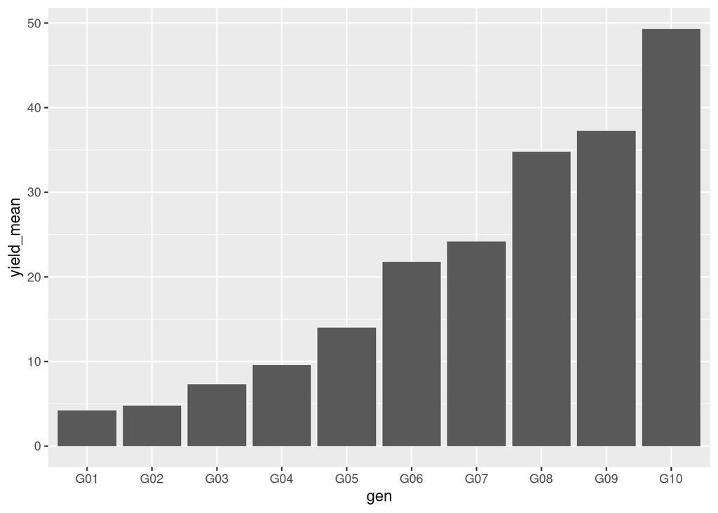

```r
ggplot(data=barley_means, aes(x=gen, y=yield_mean)) +
  geom_bar(stat="identity")
```

There are all sorts of things we can do in R with our plots. Say we wanted to change the labels on the x or y axes. We just add those using the “labs()” option:

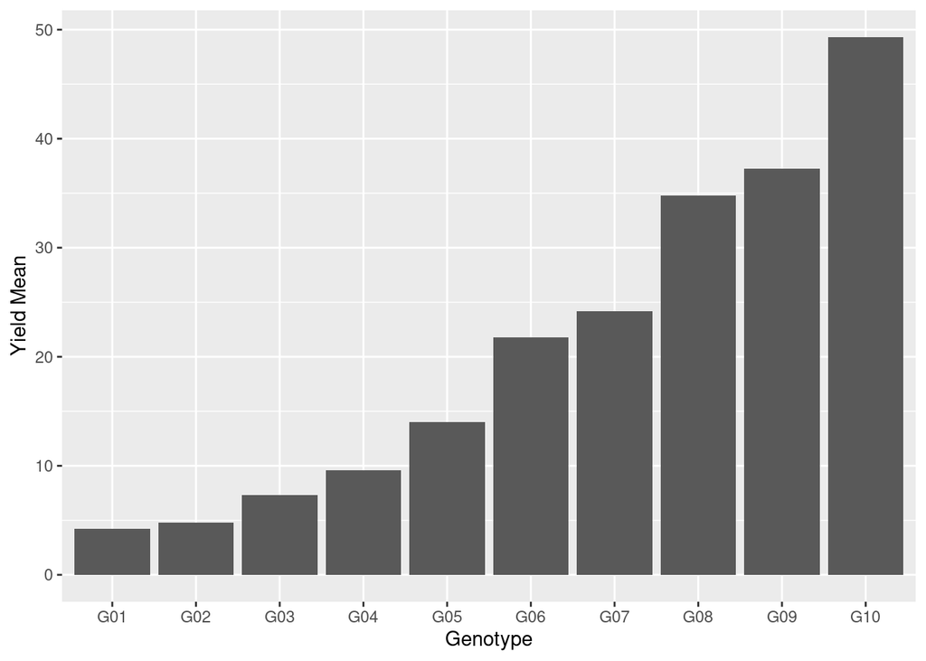

```r
ggplot(data=barley_means, aes(x=gen, y=yield_mean)) +
  geom_bar(stat="identity") +
  labs(x = "Genotype", y = "Yield Mean")
```

We can change the bar color by adding the *fill()* command to geom_bar.

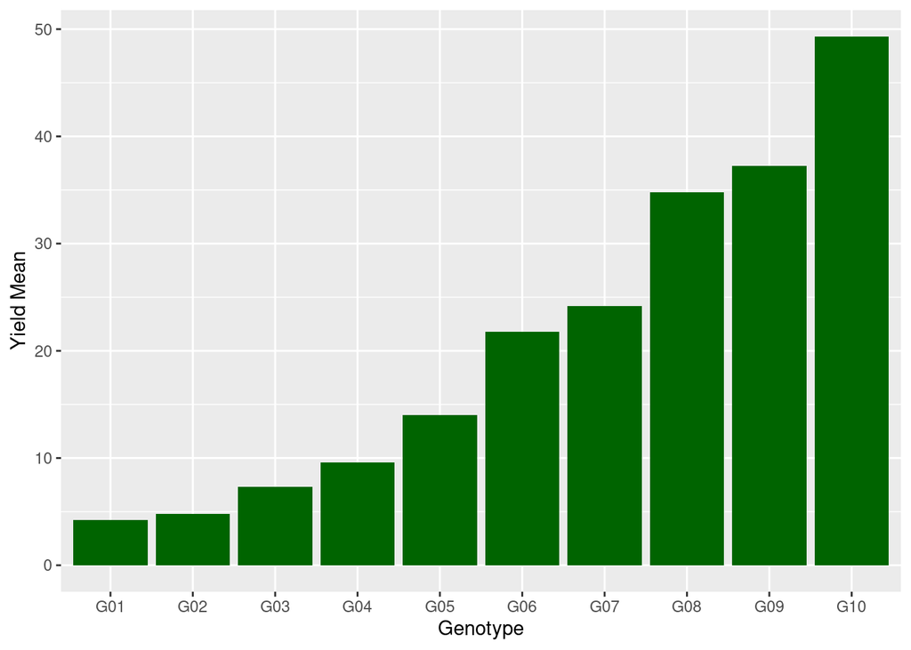

```r
ggplot(data=barley_means, aes(x=gen, y=yield_mean)) +
  geom_bar(stat="identity", fill="darkgreen") +
  labs(x = "Genotype", y = "Yield Mean")
```

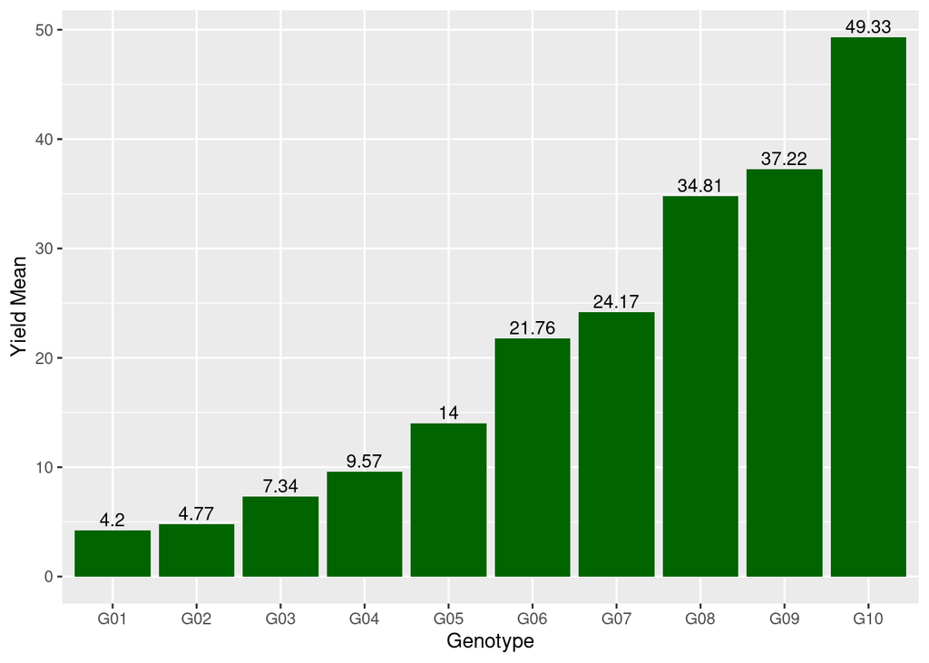

```r
ggplot(data=barley_means, aes(x=gen, y=yield_mean)) +
  geom_bar(stat="identity", fill="darkgreen") +
  labs(x = "Genotype", y = "Yield Mean") +
  geom_text(aes(label=yield_mean), vjust=-0.3, size=3.5)
```

# Practice: Beet Data

```r
beet_data = read.csv("data/beets_crd.csv")
head(beet_data)
```

|  | plot | fert | yield |
| --- | --- | --- | --- |
| 1 | 1 | None | 2.45 |
| 2 | 2 | P | 6.71 |
| 3 | 3 | K | 3.22 |
| 4 | 4 | PK | 6.34 |
| 5 | 5 | PN | 6.48 |
| 6 | 6 | KN | 3.70 |

Calculate the yield mean by fertilizer level by completing the code below.

```r
beet_means = beet_data %>%
  group_by() %>%
  summarise
```

Create a simple bar plot using ggplot() and geom_bar().

[figure not shown]

```r
ggplot(data=beet_means, aes(x= , y= )) +
  geom_bar(stat = )
```

# Practice: Potato Data

```r
potato_data = read.csv("data/potato_crd.csv")
head(potato_data)
```

|  | inf | trt | row | col |
| --- | --- | --- | --- | --- |
| 1 | 9 | F3 | 4 | 1 |
| 2 | 12 | O | 4 | 2 |
| 3 | 18 | S6 | 4 | 3 |
| 4 | 10 | F12 | 4 | 4 |
| 5 | 24 | S6 | 4 | 5 |
| 6 | 17 | S12 | 4 | 6 |

Calculate the mean infection (inf) by treatment (trt) and assign it to the data frame “potato_means”.

Use the potato_means data frame to create a simple bar plot.